# 202140090-홍기현-Assignment1

## 목차

### MyImageFilter(img0, h), myEdgeFilter(img0, sigma) Method 선언

- Assignment1 해결을 위한 메소드 선언

### Question

- **Q1.** Average Filter (3x3, 5x5, 11x11, and 15x15). Analysis of using avg filter with different kernel sizes
- **Q2.** Adding Salt and Pepper noise. Removing noise using median filter with different kernel sizes
- **Q3.** Analysis of using Gaussian kernel with differnent kernel sizes for Blur effect
- **Q4.** Show the result of edge detection

```python
import cv2
import numpy as np
import matplotlib.pyplot as plt
import math

from skimage.color import rgb2gray
from skimage.transform import resize
from scipy import signal
from scipy.fftpack import fft, fftshift
from random import random
```

**Lenna.png 불러오기 및 grey scale의 이미지로 변환**

```python
image = cv2.imread("D:\OpenCV\Lenna.png", cv2.IMREAD_GRAYSCALE)
```

**Original Lenna 이미지 출력**

[figure not shown]

```python
plt.imshow(image)
```

## Assignment1 해결을 위한 메소드 선언

### **myImageFilter(img0, h)**

```python
def myImageFilter(img0, h):

    # 입력받은 img0과 h의 size
    height, width = img0.shape
    filterHeight, filterWidth = h.shape

    # 반환할 필터링된 이미지 선언
    myImage = np.array(range(height * width)).reshape((height, width))

    # 이중 for문으로 img0에 필터를 적용한 값을 구하며, 만약 가장자리일 경우 -1로 초기화
    for i in range(0, height):
        for j in range(0, width):
            try:
                temp = 0
                for k in range(0, filterHeight):
                    for l in range(0, filterWidth):
                        # print(i, j, k, l)
                        if((int(filterHeight / 2) > k) and (int(filterWidth / 2) > l)):
                            temp += img0[i - int(filterHeight / 2) + k][j - int(filterWidth / 2) + l] * h[k][l]
                        elif((int(filterHeight / 2) > k) and (int(filterWidth / 2) <= l)):
                            temp += img0[i - int(filterHeight / 2) + k][j + l - 1] * h[k][l]
                        elif((int(filterHeight / 2) <= k) and (int(filterWidth / 2) > l)):
                            temp += img0[i + k - 1][j - int(filterWidth / 2) + l] * h[k][l]
                        else:
                            temp += img0[i + k - 1][j + l - 1] * h[k][l]

                myImage[i][j] = int(temp)

            except:
                myImage[i][j] = 0


    # 가장자리의 데이터에 가장 가까운 픽셀의 값을 대입하여 패딩
    for i in range(0, height):
        for j in range(0, width):
            if((i == 0) and (j == 0)):
                myImage[i][j] = myImage[i + 1][j + 1]
            elif(i == 0 and j == (width - 1)):
                myImage[i][j] = myImage[i + 1][j - 1]
            elif(i == (height - 1) and j == 0):
                myImage[i][j] = myImage[i - 1][j + 1]
            elif(i == (height - 1) and j == (width - 1)):
                myImage[i][j] = myImage[i - 1][j - 1]
            elif(i == 0):
                myImage[i][j] = myImage[i + 1][j]
            elif(i == (height - 1)):
                myImage[i][j] = myImage[i - 1][j]
            elif(j == 0):
                myImage[i][j] = myImage[i][j + 1]
            elif(j == (width - 1)):
                myImage[i][j] = myImage[i][j - 1]

    # 타입 변환
    myImage = np.uint8(myImage)
    return myImage
```

### **myEdgeFilter(img0, sigma)**

- 파라매터로 img0과 sigma를 받는다.
- img0은 Edge를 추출할 이미지이며, sigma는 Edge는 표준 편차이다.
- img0 이미지는 가우시안을 사용하여 Blur한다.
- Blur된 이미지는 sobelX 필터와 sobelY 필터를 통하여 x, y축의 Edge를 추출한다.
- 이를 통하여 img0의 Edge를 추출하며, 이 결과는 반환된다.

```python
def myEdgeFilter(img0, sigma):
    kernel_size = int(math.ceil(3 * sigma) * 2 + 1)

    window = signal.gaussian(kernel_size, std=sigma)
    img_blur = cv2.GaussianBlur(image, ksize=(kernel_size, kernel_size), sigmaX=sigma)

    sobelx = cv2.Sobel(img_blur, cv2.CV_64F, 1, 0, ksize=3)
    sobely = cv2.Sobel(img_blur, cv2.CV_64F, 0, 1, ksize=3)
    sobelxy = cv2.addWeighted(cv2.convertScaleAbs(sobelx), 0.5, cv2.convertScaleAbs(sobely), 0.5, 0)

    return sobelxy
```

### **saltAndPepper(image, p)**

- saltAndPepper 메소드는 입력한 이미지 image와 비율 p를 통하여 0이나 1로 잡음을 주는 메소드이다.
- 이를 위해 원본 이미지 image와 비율 p를 파라매터로 받는다.
- image는 p의 값을 기반으로 salt와 pepper noise의 비율에 따라 잡음을 추가한다.
- salt and pepper noise가 추가된 image는 반환된다.

```python
def saltAndPepper(image, p):
    output = np.zeros(image.shape, np.uint8)
    thres = 1- p
    for i in range(image.shape[0]):
        for j in range(image.shape[1]):
            rdn = random()

            if rdn < p:
                output[i][j] = 0
            elif rdn > thres:
                output[i][j] = 255
            else:
                output[i][j] = image[i][j]
    return output
```

## Question & Answer

### Q1.

**Average Filter (3x3, 5x5, 11x11, and 15x15). Analysis of using avg filter with different kernel sizes**

**평균 필터 선언 : (3 * 3), (5 * 5), (11 * 11), (15 * 15)**

```python
boxFilter3 = np.full((3, 3), 1/9)
boxFilter5 = np.full((5, 5), 1/25)
boxFilter11 = np.full((11, 11), 1/121)
boxFilter15 = np.full((15, 15), 1/225)
```

**myImageFilter(img0, h) 메소드와 평균 필터 4개를 이용하여 Convolution을 수행**

```python
image3 = myImageFilter(image, boxFilter3)
image5 = myImageFilter(image, boxFilter5)
image11 = myImageFilter(image, boxFilter11)
image15 = myImageFilter(image, boxFilter15)
```

**size가 다른 4개의 평균 필터를 적용한 Lenna 이미지 출력**

[figure not shown]

[figure not shown]

[figure not shown]

[figure not shown]

```python
plt.imshow(image3)
plt.show()
plt.imshow(image5)
plt.show()
plt.imshow(image11)
plt.show()
plt.imshow(image15)
plt.show()
```

#### 분석 결과

- Lenna 이미지에 크기가 다른 평균 필터를 적용한 결과 필터가 커질수록 점점 Blur가 되는 현상을 볼 수가 있었다.
- 예를 들어 3 x 3 필터링을 적용한 이미지는 원본 이미지에 비해 큰 변화를 느끼기 어려웠지만, 15 x 15 필터링을 적용한 경우 윤곽선이 매우 흐려지며 주위의 픽셀과 혼합되는 것을 볼 수 있었다.
- 이를 통하여 커널의 크기가 커질수록 넓은 범위를 평균하기 때문에 윤곽선이 흐려지는 것을 알 수 있었다.

### Q2.

**Adding Salt and Pepper noise. Removing noise using median filter with different kernel sizes**

**정의한 salt and pepper noise를 추가하는 메소드를 호출하며, 10% 확률로 salt를, 10%의 확률로 pepper를 추가하기 위해 0.1을 파라매터로 넘긴다.**

```python
imgSaltPepper = saltAndPepper(image, 0.1)
```

**salt and pepper noise의 추가로 원본의 이미지에서 0과 1의 정보가 랜덤하게 섞인 이미지를 획득하고 출력한다.**

[figure not shown]

```python
plt.imshow(imgSaltPepper)
```

**salt and pepper noise를 추가한 이미지에 커널의 크기가 다른 중위수 필터를 사용하여 noise의 제거 경향을 분석한다.**

```python
imgSaltPepper3 = cv2.medianBlur(imgSaltPepper, ksize=3)
imgSaltPepper5 = cv2.medianBlur(imgSaltPepper, ksize=5)
imgSaltPepper11 = cv2.medianBlur(imgSaltPepper, ksize=11)
imgSaltPepper15 = cv2.medianBlur(imgSaltPepper, ksize=15)
```

[figure not shown]

[figure not shown]

[figure not shown]

[figure not shown]

```python
plt.imshow(imgSaltPepper3)
plt.show()
plt.imshow(imgSaltPepper5)
plt.show()
plt.imshow(imgSaltPepper11)
plt.show()
plt.imshow(imgSaltPepper15)
plt.show()
```

#### 분석 결과

- Lenna 이미지에 salt and pepper noise를 추가한 후, 커널의 크기가 다른 중위수 필터 4개를 적용했다.
- 그 결과 커널의 크기가 작으면 완전히 noise를 없애지는 못하며 약간의 noise가 남지만, 기존의 원본 이미지의 윤곽선을 매우 잘 보존한다.
- 그에 비해 커널 사이즈가 커지면 noise를 매우 잘 제거하지만, 원본 이미지의 윤곽선을 잘 보존하지 못한다.
- 따라서 noise 제거 시 적절한 커널 사이즈를 선택하는 것은 매우 중요하다고 판단된다.

### Q3.

**Analysis of using Gaussian kernel with differnent kernel sizes for Blur effect**

**Lenna 원본 이미지에서 Blur Effect를 위해 다양한 커널 크기를 가진 가우스 커널 사용을 분석한다. 이를 위해 sigma를 3, 5, 11, 15로 정의하며, 이를 기반으로 커널 크기를 구하며, 가우스 필터를 적용한다.**

[figure not shown]

[figure not shown]

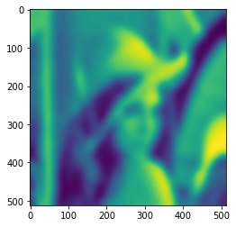

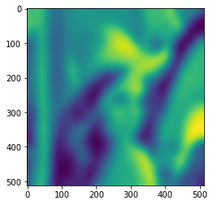

```python
sigmas = [3, 5, 11, 15]

for sigma in sigmas:
    kernel_size = int(math.ceil(3 * sigma) * 2 + 1)
    blurred_image = cv2.GaussianBlur(image, ksize=(kernel_size, kernel_size), sigmaX=sigma)

    plt.imshow(blurred_image)
    plt.show()
```

### Q4.

**Show the result of edge detection**

**Edge를 찾기 위해 정의한 myEdgeFilter(img0, sigma) 메소드를 사용한다.**  
**image는 Lenna의 이미지를 주며, sigma는 3으로 하며, sigma의 증가가 Edge 추출에 어떠한 영향을 미치는지 분석하기 위해 sigma 7에 대한 결과도 출력한다.**

```python
imgEdge = myEdgeFilter(image, 3)
```

[figure not shown]

```python
plt.imshow(imgEdge)
plt.show()
```

```python
imgEdge = myEdgeFilter(image, 7)
```

[figure not shown]

```python
plt.imshow(imgEdge)
plt.show()
```

#### 분석 결과

- Lenna의 사진을 myEdgeFilter(img0, sigma)를 통하여 Edge를 추출한 결과 Lenna의 Edge와 배경의 Edge가 추출되는 것을 볼 수 있었다.
- 특히, sigma가 증가할 수록 Edge는 두꺼워지며, 경계가 흐려진다는 사실을 알 수 있었다.
- sigma가 적으면, 깔끔한 Edge를 얻을 수 있지만, 원하지 않는 Edge까지 함께 추출될 수 있다.
- 따라서, 실제 Edge 추출 시에 적당한 sigma를 선택하는 것은 중요하다고 판단된다.